# Totem package manual

Johannes Smolander

2022-09-12

# 1 Introduction

`Totem` package is a tool designed to facilitate the inference of tree-shaped trajectories from single-cell data [1]. These include linear, bifurcating, multifurcating, and other tree-shaped trajectories ([a helpful illustration](https://academic.oup.com/view-large/figure/205480453/btaa463f2.tif)).

In trajectory inference methods like `Slingshot`[2] that require a clustering to construct the Minimum Spanning Tree (`MST`) as the backbone of the trajectory, much of the success of the trajectory inference depends on finding a good clustering that produces a biologically meaningful trajectory with the correct milestone connections. The MST construction is determined by the cluster distances of which generation is sensitive to the cluster structure, the pre-processing steps (dimensionality reduction), and how the distances are calculated.

`Totem` generates a large number of clustering results with a *k*-medoids algorithm (CLARA) and constructs an MST for each clustering. `Totem` estimates `the connectivity` of the cells (`cell connectivity`) from the MSTs, which measures how many connections the cells have on average to other clusters in the MSTs. The cell connectivity allows users to visually see which parts of the embedding are likely to be end points (leaves) and branch points of the trajectory, and the user can leverage the cell connectivity to optimize the trajectory. `Totem` uses the `Calinski-Harabasz score` and the cell connectivity to rank the clustering results.

From the ranked clusterings the user can select one or several clusterings and easily visualize the resulting MSTs. This approach is useful because finding a good clustering automatically that will also generate a sensible MST is often difficult, requiring the user to try different tools and parameters. The user can also provide `a prior clustering` to direct the search towards clusterings that are more similar with the prior clustering. `Totem` generates the pseudotime and finds a directed trajectory of the MST using `Slingshot` and can export the trajectory as R objects that are compatible with downstream analysis tools.

# 2 Installation

`Totem` can be downloaded from Bioconductor and installed by executing the following command.

```r
if(!requireNamespace("BiocManager", quietly = TRUE))
    install.packages("BiocManager")
BiocManager::install("Totem")
```

# 3 Example: Simulated dataset

In the following, we demonstate `Totem` using a simulated dataset (`binary_tree_1`) [3]. The dataset has a non-linear, tree-shaped trajectory with several branching points.

## 3.1 Setup a SingleCellExperiment object and prepare it for Totem analysis

We create a `SingleCellExperiment` object and prepare it for `Totem` analysis. At this point, it’s better to provide the full gene expression matrix and give the vector of highly variable genes later (`3.3.1 Performing dimensionality reduction`). This way all of the features can be visualized.

```r
set.seed(1234)

suppressMessages(library(Totem))
suppressMessages(library(SingleCellExperiment))
```

```r
suppressMessages(library(cowplot))
suppressMessages(library(dyndimred))
suppressMessages(library(S4Vectors))

data(binary_tree_1)

# The dataset was normalized using the LogNormalize method from the Seurat R package.
sce <- SingleCellExperiment(assays = list(counts = t(binary_tree_1$raw_data),
                                          logcounts = t(binary_tree_1$normalized_data)))
sce <- PrepareTotem(sce)
```

```
## Converting object of `matrix` class into `dgCMatrix`.
```

```
## Converting object of `matrix` class into `dgCMatrix`.
```

```
## 1128/1128 genes remain after filtering genes with only zero values.
```

## 3.2 Run Totem steps separately

### 3.2.1 Performing dimensionality reduction

The `binary_tree_1` dataset consists of 1128 genes and 929 cells. Here, we use the landmark Multi-Dimensional Scaling (LMDS) from `dyndimred` package [4] to generate a low-dimensional embedding with 5 dimensions. LMDS is faster than MDS for large datasets.

For expression matrices with tens of thousands of features, it’s highly recommended to perform feature selection beforehand (e.g., with `Seurat`). When initializing the `SingleCellExperiment` object, it’s recommended to use the whole gene expression matrix and provide the selected feature names for the `dim.red.features` parameter. Here we use all features and set `dim.red.features=NULL` because the number of features is small.

```r
print(dim(sce))
```

```
## [1] 1128  929
```

```r
sce <- RunDimRed(object = sce,
                 dim.red.method = "lmds",
                 dim.red.features = NULL,
                 dim.reduction.parameter.list = list(ndim=5))
```

```
## using 'lmds' as the dimensionality reduction method
```

If the user wants to use a custom embedding instead, this can be provided through the `reducedDim` function.

```r
# extract the generated embedding and set it again into the same slot
own_dim_red <- reducedDim(sce)
reducedDim(sce,type = "lmds") <- own_dim_red # use any name
```

### 3.2.2 Generating a two-dimensional embedding for visualization

```r
dim_red <- dimred_mds(binary_tree_1$normalized_data,ndim=2)
```

### 3.2.3 Clustering

After dimensionality reduction, the next step is to perform clustering that involves running the k-medoids (CLARA) algorithm a large number of times (default 10k). The idea is to generate clusterings that are dissimilar and later select clusterings to use as the basis for `Slingshot` to generate directed, tree-shaped trajectories.

The user needs to specify the range of the *k* values (default `3:20`), the minimum number of cells per cluster (default `5`), and the initial total number of clusterings (default `10000`). The second parameter (`min.cluster.size`) determines the clusterings that are filtered out because they include too small clusters. The filtering step is also important because the Slingshot distance method can encounter errors if the number of features in the dimensionally reduced data exceeds the minimum cluster size.

```r
sce <- RunClustering(sce,
                         k.range = 3:20,
                         min.cluster.size = 5,
                         N.clusterings=10000)
```

```
## using lmds as the dimensional reduced data
```

```
## number of clustering results: 8830
```

### 3.2.4 Visualizing cell connectivity

The cell connectivity is calculated by averaging the connectivity vectors of all the clusterings and MSTs. Each individual connectivity vector is calculated by counting how many connections each cluster has in an MST with the other clusters divided by the number of clusters.

The example below visualizes the cell connectivity for the `binary_tree_1` dataset. The local changes in the connectivity indicate milestone transitions that are relevant to model. The visualization helps the user to find an optimal topology. Cell populations that have a low level of connectivity are likely to be leaf/end nodes of the tree, and the cell populations that have a high connectivity are likely to be at the branching points of the trajectory. This can also be useful for locating milestones that are not distinguishable in the visualization but are distinct in the embedding that is used as input in the clustering step.

```
## Coloring by expression
```

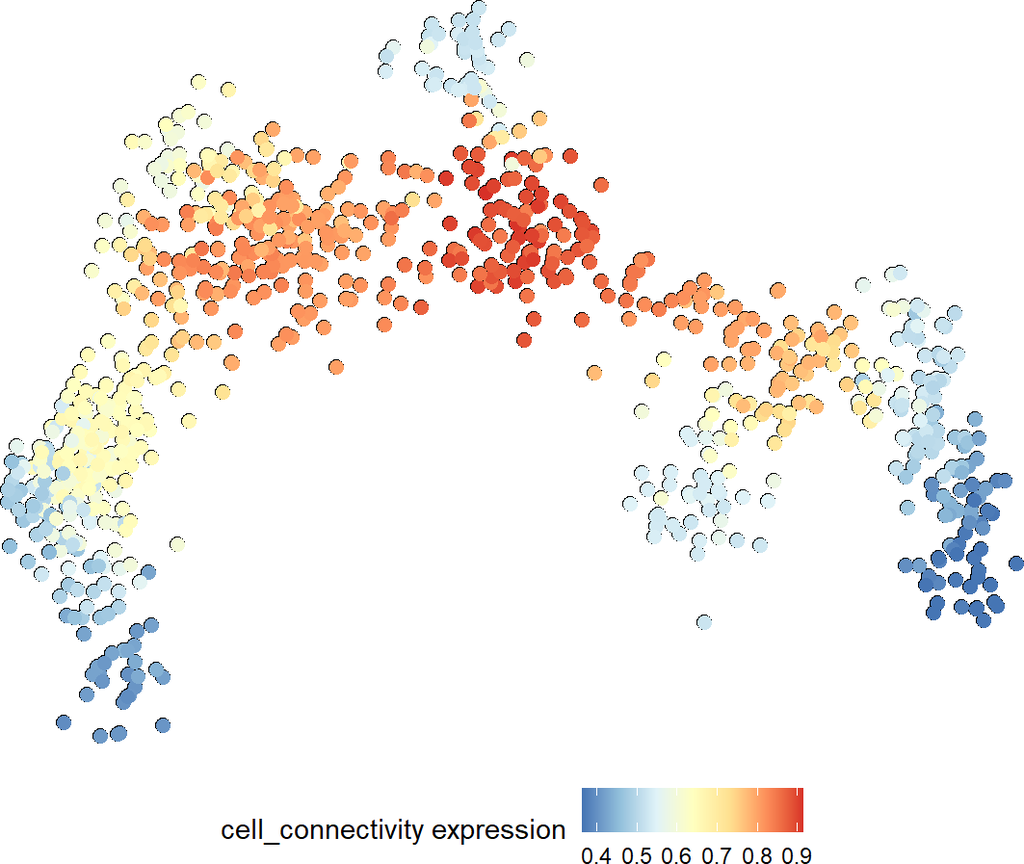

```r
VizCellConnectivity(sce,custom.dim.red = dim_red)
```

### 3.2.5 Clustering selection

In addition, the user can set `selection.stratified=TRUE` if the number of clusters in the selected clusterings to vary evenly. This generates more versatile clusterings.

The number of selected clusters is controlled by the `selection.N.models` parameter. If the value is an integer, the function picks a set of top clusterings matching to this number. If the value is a vector of integers, this selects a set of clusterings of which position in the ranked list corresponds to the integers (e.g., 2:4 would select the clusterings ranked 2,3, and 4).

It should be noted that even though the set of clustering results is large and includes highly versatile clustering results, it is possible that the algorithm cannot find a clustering that consistent with the cell connectivity. This can happen especially when some cell types are extremely prevalent and some are extremely rare. In this case, the user should increase the upper limit of the number of clusters in `RunClustering` and use `MergeClusters` to merge the subpopulations of the large cell types.

```r
sce <- SelectClusterings(sce,selection.method = 1,
                       selection.N.models = 10,
                       selection.stratified=FALSE,
                       prior.clustering = NULL)
```

### 3.2.6 Visualizing the selected clusterings and their MSTs

We visualize the the selected clusterings and their MSTs using `VizMST` function. To construct the MST, `Totem` uses the Slingshot distance metric based on a Mahalanobis-like metric that takes into account the distance, spread, and shape of the clusters.

```r
ReturnTrajNames(sce)
```

```
##  [1] "13.127" "10.131" "11.60"  "13.268" "13.231" "14.198" "11.508" "12.290"
##  [9] "9.67"   "11.353"
```

```
## Coloring by milestone
```

```
## Using milestone_percentages from trajectory
```

```
## Coloring by milestone
## Using milestone_percentages from trajectory
```

```
## Coloring by milestone
## Using milestone_percentages from trajectory
```

```
## Coloring by milestone
## Using milestone_percentages from trajectory
```

```
## Coloring by milestone
## Using milestone_percentages from trajectory
```

```
## Coloring by milestone
## Using milestone_percentages from trajectory
```

```
## Coloring by milestone
## Using milestone_percentages from trajectory
```

```
## Coloring by milestone
## Using milestone_percentages from trajectory
```

```
## Coloring by milestone
## Using milestone_percentages from trajectory
```

```
## Coloring by milestone
## Using milestone_percentages from trajectory
```

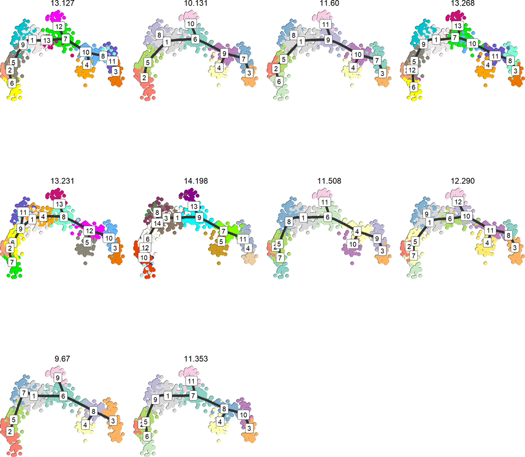

```r
VizMST(sce,clustering.names = ReturnTrajNames(sce),custom.dim.red = dim_red)
```

We can print the MST network with `ReturnMSTNetwork` function.

```r
ReturnMSTNetwork(sce,clustering.name = "13.127")
```

```
## using lmds as the dimensional reduced data
```

```
##    1 2 3 4 5 6 7 8 9 10 11 12 13
## 1  0 0 0 0 0 0 0 0 1  0  0  0  1
## 2  0 0 0 0 1 0 0 0 0  0  0  0  0
## 3  0 0 0 0 0 0 0 0 0  0  1  0  0
## 4  0 0 0 0 0 0 0 0 0  1  0  0  0
## 5  0 1 0 0 0 1 0 0 1  0  0  0  0
## 6  0 0 0 0 1 0 0 0 0  0  0  0  0
## 7  0 0 0 0 0 0 0 0 0  1  0  1  1
## 8  0 0 0 0 0 0 0 0 0  1  1  0  0
## 9  1 0 0 0 1 0 0 0 0  0  0  0  0
## 10 0 0 0 1 0 0 1 1 0  0  0  0  0
## 11 0 0 1 0 0 0 0 1 0  0  0  0  0
## 12 0 0 0 0 0 0 1 0 0  0  0  0  0
## 13 1 0 0 0 0 0 1 0 0  0  0  0  0
## attr(,"class")
## [1] "mst"
```

### 3.2.7 Perform Slingshot smoothing for selected clusterings

We perform the Slingshot smoothing to generate the pseudotime and a directed trajectory for the selected clusterings. The MSTs will be the same that were visualized previously, unless the user changes the distance method through `slingshot.parameter.list` parameter. The starting (root) clusters will be selected randomly, but they can be changed using `ChangeTrajRoot` function for each trajectory individually (see below).

```r
sce <- RunSmoothing(sce)
```

We visualize the smoothed trajectories with `VizSmoothedTraj` function. These can be only trajectories that have been smoothed with `RunSmoothing` function.

```r
ReturnTrajNames(sce)
```

```
##  [1] "13.127" "10.131" "11.60"  "13.268" "13.231" "14.198" "11.508" "12.290"
##  [9] "9.67"   "11.353"
```

```
## Coloring by milestone
```

```
## Using milestone_percentages from trajectory
```

```
## Coloring by milestone
```

```
## Using milestone_percentages from trajectory
```

```
## Coloring by milestone
```

```
## Using milestone_percentages from trajectory
```

```
## Coloring by milestone
```

```
## Using milestone_percentages from trajectory
```

```
## Coloring by milestone
```

```
## Using milestone_percentages from trajectory
```

```
## Coloring by milestone
```

```
## Using milestone_percentages from trajectory
```

```
## Coloring by milestone
```

```
## Using milestone_percentages from trajectory
```

```
## Coloring by milestone
```

```
## Using milestone_percentages from trajectory
```

```
## Coloring by milestone
```

```
## Using milestone_percentages from trajectory
```

```
## Coloring by milestone
```

```
## Using milestone_percentages from trajectory
```

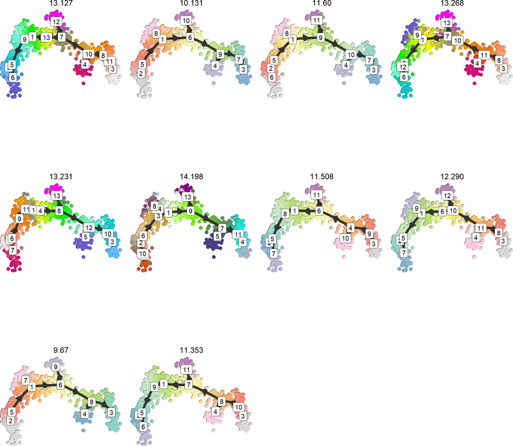

```r
VizSmoothedTraj(sce,
                traj.names = ReturnTrajNames(sce),
                custom.dim.red = dim_red,plot.pseudotime = FALSE)
```

We can print the milestone network of a trajectory by `ReturnSmoothedTrajNetwork` function.

```r
ReturnSmoothedTrajNetwork(sce,clustering.name = "13.127")
```

```
##    from to    length directed
## 1     3 11 0.1647447     TRUE
## 2    11  8 0.1249941     TRUE
## 3     8 10 0.1706022     TRUE
## 4    10  7 0.2870571     TRUE
## 5     7 13 0.1649305     TRUE
## 6    13  1 0.1985521     TRUE
## 7     1  9 0.1690487     TRUE
## 8     9  5 0.3066044     TRUE
## 9     5  2 0.1623079     TRUE
## 10    5  6 0.2108482     TRUE
## 11    7 12 0.2448109     TRUE
## 12   10  4 0.1821710     TRUE
```

### 3.2.8 Changing the root cluster

At this point, we can decide that we think the trajectory `13.127` feels optimal and want to take it for further analysis.

The current root node is `3`, and we can use `ChangeTrajRoot` function to change it to e.g. `12`. Currently, the function re-runs the Slingshot smoothing and might take long with large datasets.

```r
sce <- ChangeTrajRoot(sce,traj.name="13.127",root.cluster=12)
```

Visualize the root-adjusted trajectory.

```
## Coloring by milestone
```

```
## Using milestone_percentages from trajectory
```

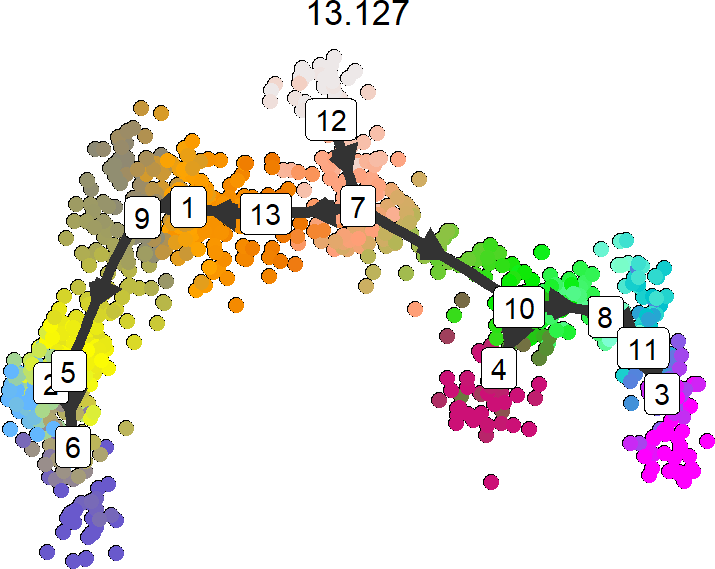

```r
VizSmoothedTraj(sce,
                traj.names = "13.127",
                custom.dim.red = dim_red,plot.pseudotime = FALSE)
```

```
## Pseudotime not provided, will calculate pseudotime from root milestone
```

```
## root cell or milestone not provided, trying first outgoing milestone_id
```

```
## Using '12' as root
```

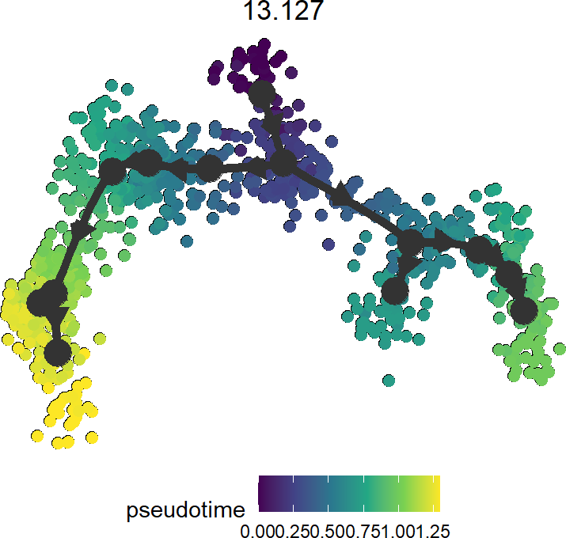

```r
VizSmoothedTraj(sce,
                traj.names = "13.127",
                custom.dim.red = dim_red,plot.pseudotime = TRUE)
```

Print its milestone network.

```r
ReturnSmoothedTrajNetwork(sce,clustering.name = "13.127")
```

```
##    from to    length directed
## 1    12  7 0.2448109     TRUE
## 2     7 13 0.1649305     TRUE
## 3    13  1 0.1985521     TRUE
## 4     1  9 0.1690487     TRUE
## 5     9  5 0.3066044     TRUE
## 6     5  2 0.1623079     TRUE
## 7     5  6 0.2108482     TRUE
## 8     7 10 0.2870571     TRUE
## 9    10  8 0.1706022     TRUE
## 10    8 11 0.1249941     TRUE
## 11   11  3 0.1647447     TRUE
## 12   10  4 0.1821710     TRUE
```

### 3.2.9 Merging clusters

Sometimes it can be useful to merge clusters. The k-medoids clustering algorithm can’t always generate proper-sized clusters when some cell types are rare and some are highly prevalent in the data. In cases like this, it’s better to increase the upper limit of the number of clusters in `RunClustering` and merge the sub-clusters of large cell types manually. Note that this function overwrites the original clustering.

```r
sce <- MergeClusters(sce,clustering.name="13.127",
                     merged.clusters = c(11,3),
                     merged.name = 3)
```

Visualize the MST.

```
## Coloring by milestone
```

```
## Using milestone_percentages from trajectory
```

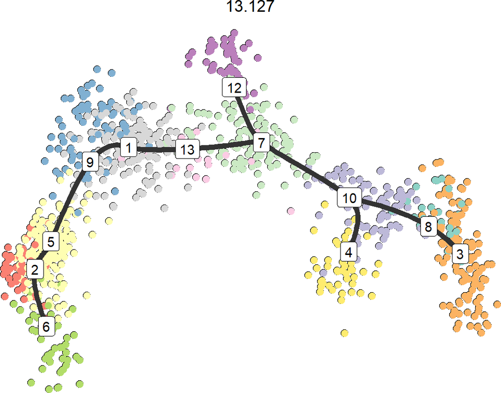

```r
VizMST(sce,clustering.names = "13.127",custom.dim.red = dim_red)
```

### 3.2.10 Visualizing gene expression

`VizFeatureExpression` function can be used to visualize expression of one or several features. `traj.name` parameter can be left empty.

```
## Coloring by expression
```

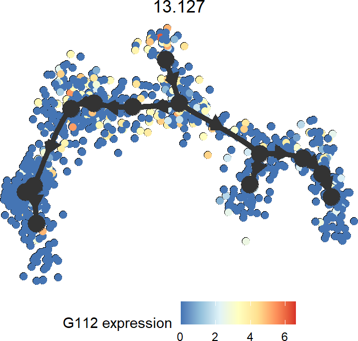

```r
VizFeatureExpression(sce,traj.name = "13.127",
                     feature.names = "G112",
                     custom.dim.red = dim_red,
                     plot.trajectory = TRUE)
```

### 3.2.11 Visualizing a user-provided clustering

`VizClustering` function can be used if the user wants to visualize a custom clustering or some other character vector over the two-dimensional visualization. By default, the function also creates an MST based on the distance method and visualizes it.

```
## Coloring by milestone
```

```
## Using milestone_percentages from trajectory
```

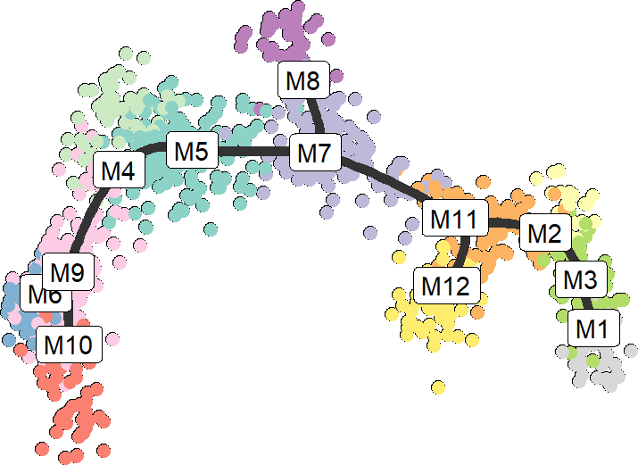

```r
VizClustering(sce,clustering = binary_tree_1$clustering,custom.dim.red = dim_red)
```

### 3.2.12 Return dynwrap and Slingshot objects for further downstream analysis

We can return a `dynwrap` object of a trajectory with `ReturnDynwrapObject` function or a `PseudotimeOrdering` object with `ReturnSlingshotObject`. The objects can then be used downstream for example to perform differential expression analysis using tools like [dyno](https://dynverse.org/dyno/) or [tradeSeq](https://www.bioconductor.org/packages/release/bioc/html/tradeSeq.html).

```r
dynwrap_object <- ReturnDynwrapObject(sce,traj.name="13.127")
slingshot_object <- ReturnSlingshotObject(sce,traj.name="13.127")
```

## 3.3 Limitations

`Totem` has the same limitations with respect to trajectory complexity as the `Slingshot` trajectory inference method and the `dynverse` trajectory framework that `Totem` uses.

Currently, it is not possible to sensibly create *converging* trajectories, where the cells converge to a single point from multiple root clusters. This is because `dynplot` will not generate the correct pseudotime for multi-root trajectories. However, if the user wants to only visualize a converging trajectory without the correct pseudotime, it is possible to hand-edit the milestone network of the `dynwrap` object and flip the direction of each milestone pair.

```r
  milestone_network <- dynwrap_object$milestone_network
  from_ <- milestone_network$from
  to_ <- milestone_network$to
  milestone_network$from <- to_
  milestone_network$to <- from_
  dynwrap_object$milestone_network <- milestone_network

  metadata(sce)$totem$dynwrap_trajectory[["13.127"]] <- dynwrap_object
```

```
## Coloring by milestone
```

```
## Using milestone_percentages from trajectory
```

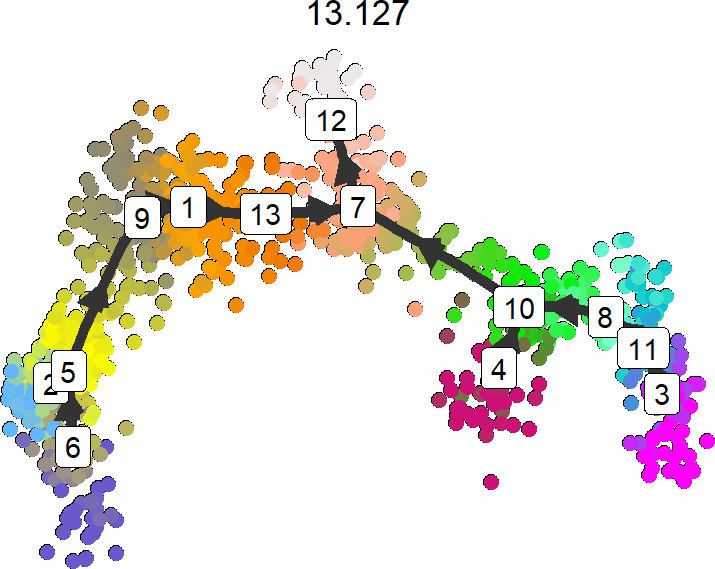

```r
VizSmoothedTraj(sce,
                traj.names = "13.127",
                custom.dim.red = dim_red,plot.pseudotime = FALSE)
```

```
## Pseudotime not provided, will calculate pseudotime from root milestone
```

```
## root cell or milestone not provided, trying first outgoing milestone_id
```

```
## Using '2' as root
```

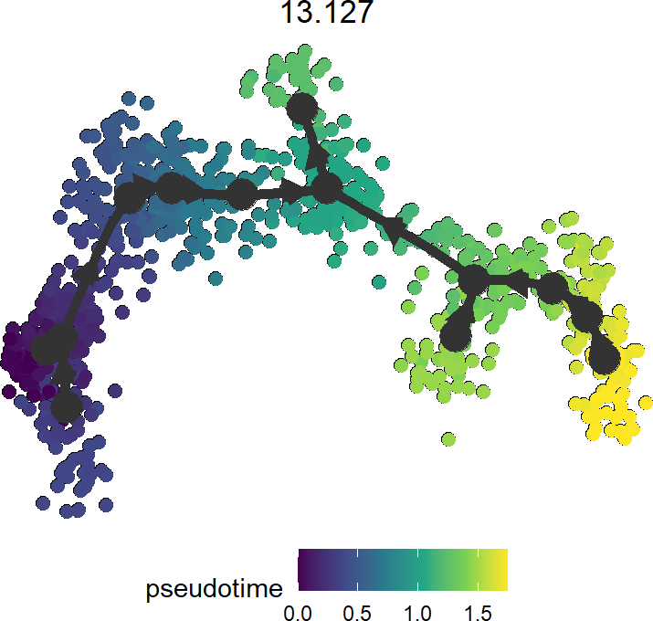

```r
VizSmoothedTraj(sce,
                traj.names = "13.127",
                custom.dim.red = dim_red,plot.pseudotime = TRUE)
```

Similarly, it is possible to visualize trajectories that have both *diverging* and *converging* parts, diverging meaning that the cells diverge from a single point. As previously, the milestone network needs to be hand-edited and saved back to the `SingleCellExperiment` object.

In addition, `Totem` cannot generate disconnected trajectories or trajectories that have cycles.

## 3.4 Tips

- If the objective is to generate a trajectory that is in line with a visualization, such as UMAP or t-SNE, then the easiest way to obtain accurate trajectories is to use the embedding of the visualization as the input data in the clustering. See the earlier part `Performing dimensionality reduction` for how to set a custom matrix as the input data.
- If using UMAP or t-SNE, the parameters affect how the visualization will look like. For example, the parameters of the UMAP function in the `dyndimred` R package will create a more compact visualization compared to Seurat, although both use the UWOT R package to perform UMAP.
- Sometimes the k-medoids algorithm may not work well with PCA if the number principal components is high (e.g. 30) because the generated clustering results contain many small clusters (1 or 2 cells). If that happens, it’s better to use LMDS, UMAP, or other dimensionality reduction method.
- If the dataset includes extremely rare cell types and extremely prevalent cell types at the same time, the k-medoids might not work properly. The result can contain many subpopulations for the large cell types, in which case the `MergeClusters` function can be used to merge the subpopulations.

# 4 References

1. Johannes Smolander, Sini Junttila, Laura L Elo, Totem: a user-friendly tool for clustering-based inference of tree-shaped trajectories from single-cell data. bioRxiv.
2. Street, K., Risso, D., Fletcher, R. et al. Slingshot: cell lineage and pseudotime inference for single-cell transcriptomics. BMC Genomics 19, 477 (2018). https://doi.org/10.1186/s12864-018-4772-0
3. Robrecht Cannoodt, Wouter Saelens, Helena Todorov, & Yvan Saeys. (2018). Single-cell -omics datasets containing a trajectory (2.0.0) [Data set]. Zenodo. https://doi.org/10.5281/zenodo.1443566
4. Saelens, W., Cannoodt, R., Todorov, H. et al. A comparison of single-cell trajectory inference methods. Nat Biotechnol 37, 547-554 (2019). https://doi.org/10.1038/s41587-019-0071-9

# 5 Contact information

If you have questions related to `Totem`, please contact us [here](https://github.com/elolab/Totem).